# Tarea 1: caja de herramientas de pronóstico

## 4.8 Holt lineal sobre `LakeHuron`

### 4.8.1 Serie y patrón antes del ajuste

```r
x <- resultados[[8]]
mostrar_serie(x)
```

| Campo | Valor |
| --- | --- |
| Objeto de R | LakeHuron |
| Fuente documentada en help() | Brockwell y Davis (1991), Time Series and Forecasting Methods, serie A, p. 555; y Brockwell y Davis (1996), secciones 5.1 y 7.6. |
| Unidad | nivel en pies |
| Frecuencia | 1 |
| Rango | 1875-01-01 a 1972-01-01 |
| Observaciones | 98 |

**Lectura previa del patrón.** La serie combina un nivel local con cambios de pendiente y no tiene estacionalidad. Holt permite actualizar ambos estados, aunque el resultado debe compararse con el ingenuo.

#### 4.8.1.1 Ljung–Box sobre la serie

1. **Hipótesis:**

$$\begin{aligned}
H_0 &: \rho_1 = \rho_2 = \cdots = \rho_m = 0, \\
H_1 &: \exists\,h \in \{1,\ldots,m\}: \rho_h \neq 0.
\end{aligned}$$

2. **Estadístico y distribución bajo H₀:**

$$\begin{aligned}
Q_m &= T(T+2) \sum_{h=1}^{m} \frac{r_h^2}{T-h}, \\[4pt]
Q_m \mid H_0 &\approx \chi^2_{21}.
\end{aligned}$$

3. **Región de rechazo con α = 0.05:**

$$Q_m > \chi^2_{0.95;21} = 32.6706$$

4. **Valor observado y valor p:**

$$Q_{m,\mathrm{obs}} = 192.6058, \qquad p = 1.03 \times 10^{-29}$$

5. **Decisión:** Se rechaza H0 al nivel del 5 %.
6. **Lectura en contexto:** La serie no se comporta como ruido blanco: existe dependencia conjunta antes de ajustar el método.

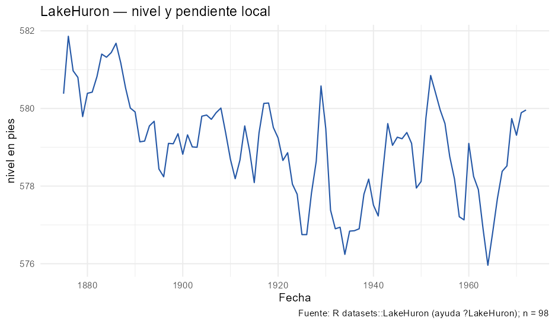

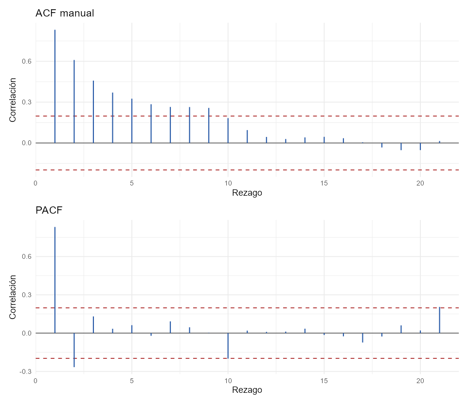

### 4.8.2 Selección de $\alpha$ y $\beta$, ajuste y validación

```r
mostrar_ajuste(x)
```

El tramo de estimación contiene **86 observaciones** y la validación conserva las últimas **12 observaciones**. El ajuste seleccionado es **alpha=0.95; beta=0.05**.

El óptimo cae en el borde de la rejilla. Esto indica que la búsqueda empuja el parámetro hacia el extremo permitido y que el modelo o la rejilla deben interpretarse con cautela.

| Muestra | MSE | MAD | MAPE | MASE |
| --- | --- | --- | --- | --- |
| Estimación: pronóstico de un paso | 0.5897 | 0.5983 | 0.1033 | 1.0422 |
| Validación: método | 2.1430 | 1.2000 | 0.2078 | 2.0902 |
| Validación: Ingenuo | 2.2384 | 1.2425 | 0.2151 | 2.1642 |

Con el mismo origen y horizonte, el método sí supera al referente según MASE: 2.090 frente a 2.164.

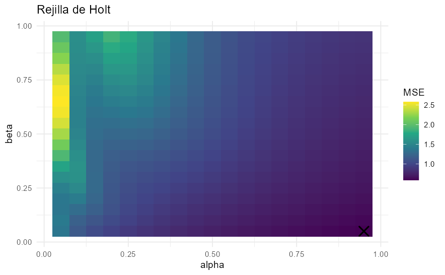

```r
figuras_md(x$figuras["optimizacion"])
```

La pareja seleccionada es $\alpha=0.95$ y $\beta=0.05$, ambos en bordes de la rejilla. El nivel reacciona casi por completo al dato nuevo, mientras la pendiente cambia lentamente. Esto señala que el método está cerca de un comportamiento ingenuo con una tendencia suavizada débil.

### 4.8.3 Validación de los errores

```r
mostrar_diagnosticos(x)
```

Los diagnósticos utilizan **85 errores efectivos** después de retirar las posiciones de calentamiento.

#### 4.8.3.1 Media cero de los errores

1. **Hipótesis:**

$$\begin{aligned}
H_0 &: \mu_e = 0, \\
H_1 &: \mu_e \neq 0.
\end{aligned}$$

2. **Estadístico y distribución bajo H₀:**

$$\begin{aligned}
t &= \frac{\bar e}{s_e/\sqrt{n_e}}, \\[4pt]
t \mid H_0 &\sim t_{84}.
\end{aligned}$$

3. **Región de rechazo con α = 0.05:**

$$|t| > t_{0.975;84} = 1.9886$$

4. **Valor observado y valor p:**

$$t_{\mathrm{obs}} = 0.0494, \qquad p = 0.9607$$

5. **Decisión:** No se rechaza H0 al nivel del 5 %.
6. **Lectura en contexto:** No se detecta sesgo medio en los errores al 5 %.

#### 4.8.3.2 Ljung–Box sobre los errores

1. **Hipótesis:**

$$\begin{aligned}
H_0 &: \rho_1 = \rho_2 = \cdots = \rho_m = 0, \\
H_1 &: \exists\,h \in \{1,\ldots,m\}: \rho_h \neq 0.
\end{aligned}$$

2. **Estadístico y distribución bajo H₀:**

$$\begin{aligned}
Q_m &= T_e(T_e+2) \sum_{h=1}^{m} \frac{r_h^2}{T_e-h}, \\[4pt]
Q_m \mid H_0 &\approx \chi^2_{m-p} = \chi^2_{19}.
\end{aligned}$$

3. **Región de rechazo con α = 0.05:**

$$Q_m > \chi^2_{0.95;19} = 30.1435$$

4. **Valor observado y valor p:**

$$Q_{m,\mathrm{obs}} = 29.1532, \qquad p = 0.0636$$

5. **Decisión:** No se rechaza H0 al nivel del 5 %.
6. **Lectura en contexto:** No se detecta autocorrelación conjunta residual al 5 %.

#### 4.8.3.3 Jarque–Bera

1. **Hipótesis:**

$$\begin{aligned}
H_0 &: A = 0 \text{ y } K = 3, \\
H_1 &: A \neq 0 \text{ o } K \neq 3.
\end{aligned}$$

2. **Estadístico y distribución bajo H₀:**

$$\begin{aligned}
JB &= \frac{n}{6}\left[A^2 + \frac{(K-3)^2}{4}\right], \\[4pt]
JB \mid H_0 &\approx \chi^2_2.
\end{aligned}$$

3. **Región de rechazo con α = 0.05:**

$$JB > \chi^2_{0.95;2} = 5.9915$$

4. **Valor observado y valor p:**

$$JB_{\mathrm{obs}} = 2.4179, \qquad p = 0.2985$$

5. **Decisión:** No se rechaza H0 al nivel del 5 %.
6. **Lectura en contexto:** No se rechaza la compatibilidad aproximada con normalidad.

#### 4.8.3.4 Durbin–Watson

1. **Hipótesis:**

$$\begin{aligned}
H_0 &: \rho_1 = 0, \\
H_1 &: \rho_1 > 0.
\end{aligned}$$

2. **Estadístico y referencia:**

$$\begin{aligned}
d &= \frac{\sum_{t=2}^{n_e}(e_t-e_{t-1})^2}{\sum_{t=1}^{n_e}e_t^2}, \\[4pt]
d_L, d_U &\text{ dependen de } n_e \text{ y del número de regresores}.
\end{aligned}$$

3. **Región de decisión con α = 0.05:**

$$\begin{cases} d<d_L &\Rightarrow \text{ rechazar } H_0, \\[2pt] d>d_U &\Rightarrow \text{ no rechazar } H_0, \\[2pt] d_L\le d\le d_U &\Rightarrow \text{ resultado inconcluso}. \end{cases}$$

4. **Valor observado:**

$$d_{\mathrm{obs}} = 1.5119, \qquad p = \mathrm{NA}$$

5. **Decisión:** no se calcula una decisión formal; este método no tiene una matriz de diseño fija (no es una regresión), y la rúbrica exige las cotas $d_L$/$d_U$ únicamente para los tres ejemplos de tendencia.
6. **Lectura en contexto:** valores muy inferiores a 2 son compatibles descriptivamente con autocorrelación positiva, pero no sustituyen una decisión formal.

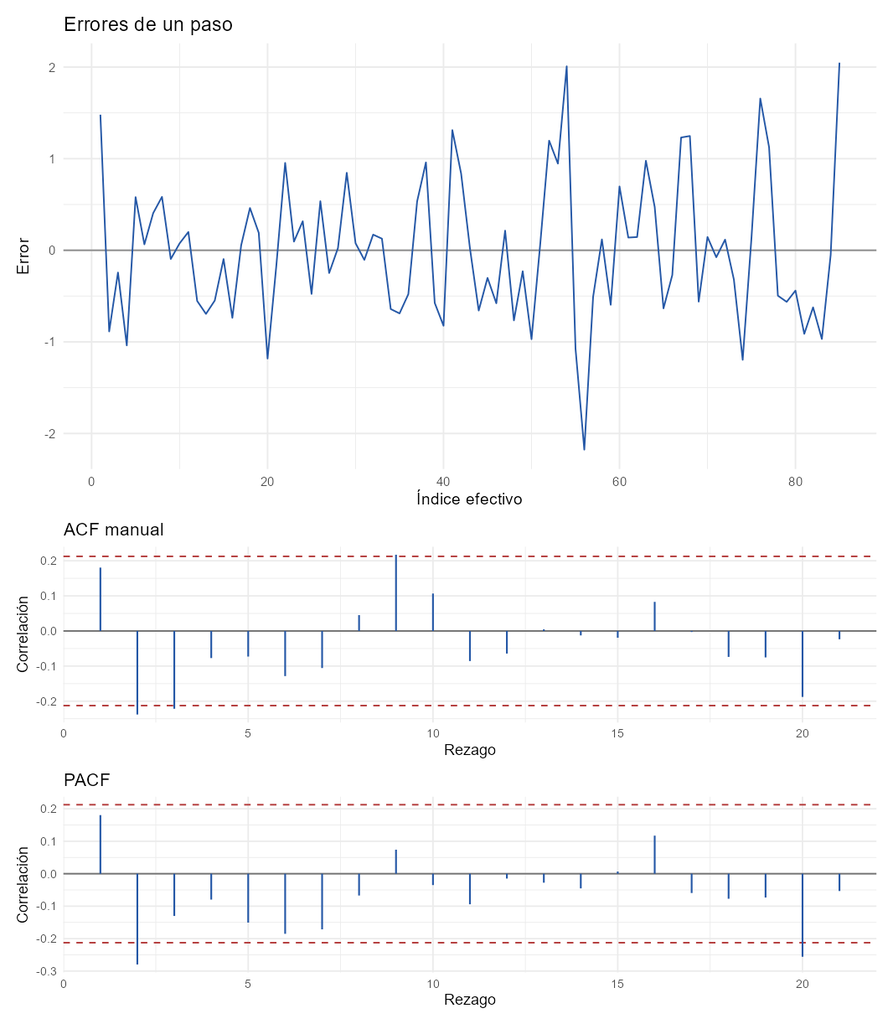

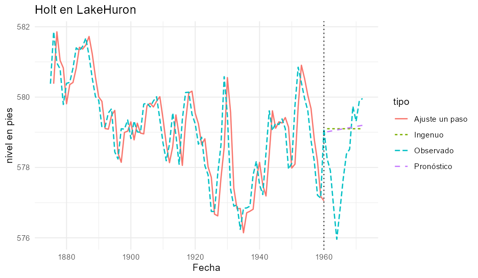

### 4.8.4 Conclusión y recomendación

```r
cierre_md(x)
```

**Conclusión.** Se ajustó Holt con alpha=0.95; beta=0.05. En las 12 observaciones de validación obtuvo MSE = 2.143, MAD = 1.200, MAPE = 0.208 y MASE = 2.090. El referente ingenuo produjo MASE = 2.164. En los errores, Ljung–Box dio p = 0.0636 y la prueba de media cero dio p = 0.9607.

**Recomendación.** El resultado podría servir a un gestor que necesite nivel y pendiente local del lago solamente hasta un horizonte de 12 años. Su límite principal es que las constantes están en bordes de la rejilla y la ganancia frente al ingenuo es pequeña; esto se evidencia con MASE = 2.090 y p de Ljung–Box residual = 0.0636.

# 5 Contraejemplo: media recursiva sobre `sunspot.year`

Este ejemplo repite el protocolo con una elección deliberadamente incorrecta. La media recursiva supone un nivel aproximadamente constante, mientras `sunspot.year` presenta ciclos solares pronunciados.

## 5.1 Serie y contradicción del supuesto

```r
x <- resultado_contra
# La lectura se agrega con el mismo identificador utilizado por el contraejemplo.
lecturas[["09-contraejemplo"]] <- "La gráfica presenta ciclos persistentes y la ACF conserva dependencia en varios rezagos. Este patrón contradice directamente el supuesto de nivel constante de la media recursiva."
mostrar_serie(x)
```

| Campo | Valor |
| --- | --- |
| Objeto de R | sunspot.year |
| Fuente documentada en help() | Tong (1996), Non-Linear Time Series, Clarendon Press, p. 471. |
| Unidad | número anual de manchas solares |
| Frecuencia | 1 |
| Rango | 1700-01-01 a 1988-01-01 |
| Observaciones | 289 |

**Lectura previa del patrón.** La gráfica presenta ciclos persistentes y la ACF conserva dependencia en varios rezagos. Este patrón contradice directamente el supuesto de nivel constante de la media recursiva.

#### 5.1.0.1 Ljung–Box sobre la serie

1. **Hipótesis:**

$$\begin{aligned}
H_0 &: \rho_1 = \rho_2 = \cdots = \rho_m = 0, \\
H_1 &: \exists\,h \in \{1,\ldots,m\}: \rho_h \neq 0.
\end{aligned}$$

2. **Estadístico y distribución bajo H₀:**

$$\begin{aligned}
Q_m &= T(T+2) \sum_{h=1}^{m} \frac{r_h^2}{T-h}, \\[4pt]
Q_m \mid H_0 &\approx \chi^2_{24}.
\end{aligned}$$

3. **Región de rechazo con α = 0.05:**

$$Q_m > \chi^2_{0.95;24} = 36.4150$$

4. **Valor observado y valor p:**

$$Q_{m,\mathrm{obs}} = 879.0558, \qquad p = 3.96 \times 10^{-170}$$

5. **Decisión:** Se rechaza H0 al nivel del 5 %.
6. **Lectura en contexto:** La serie no se comporta como ruido blanco: existe dependencia conjunta antes de ajustar el método.

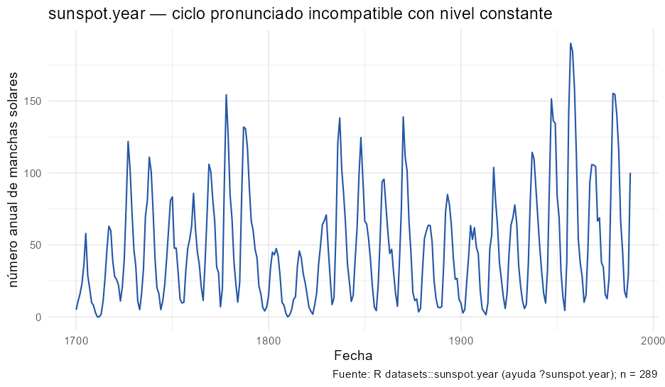

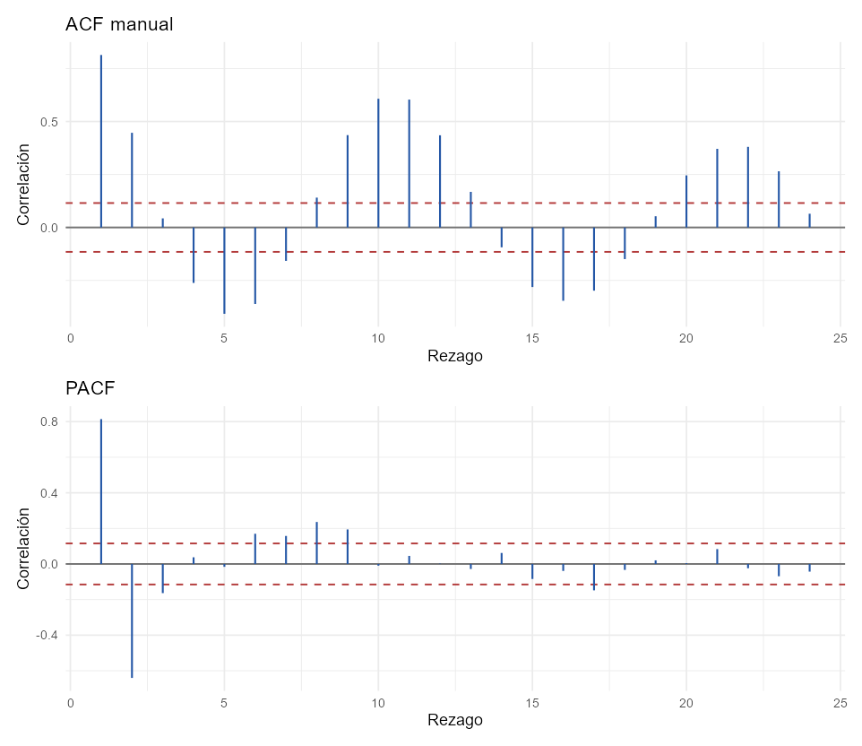

## 5.2 Ajuste y validación

```r
mostrar_ajuste(x)
```

El tramo de estimación contiene **277 observaciones** y la validación conserva las últimas **12 observaciones**. El ajuste seleccionado es **media=47.25**.

Este método no requiere seleccionar parámetros mediante una rejilla; sus parámetros se estiman directamente con el tramo de estimación.

| Muestra | MSE | MAD | MAPE | MASE |
| --- | --- | --- | --- | --- |
| Estimación: pronóstico de un paso | 1482.9305 | 29.6881 | NA | 1.7093 |
| Validación: método | 3716.4252 | 49.7825 | 79.0584 | 2.8663 |
| Validación: Ingenuo | 7185.2092 | 67.3750 | 69.8293 | 3.8792 |

Con el mismo origen y horizonte, el método sí supera al referente según MASE: 2.866 frente a 3.879.

## 5.3 Diagnósticos del fallo

```r
mostrar_diagnosticos(x)
```

Los diagnósticos utilizan **276 errores efectivos** después de retirar las posiciones de calentamiento.

#### 5.3.0.1 Media cero de los errores

1. **Hipótesis:**

$$\begin{aligned}
H_0 &: \mu_e = 0, \\
H_1 &: \mu_e \neq 0.
\end{aligned}$$

2. **Estadístico y distribución bajo H₀:**

$$\begin{aligned}
t &= \frac{\bar e}{s_e/\sqrt{n_e}}, \\[4pt]
t \mid H_0 &\sim t_{275}.
\end{aligned}$$

3. **Región de rechazo con α = 0.05:**

$$|t| > t_{0.975;275} = 1.9686$$

4. **Valor observado y valor p:**

$$t_{\mathrm{obs}} = 3.0642, \qquad p = 0.0024$$

5. **Decisión:** Se rechaza H0 al nivel del 5 %.
6. **Lectura en contexto:** Los errores presentan sesgo medio estadísticamente detectable.

#### 5.3.0.2 Ljung–Box sobre los errores

1. **Hipótesis:**

$$\begin{aligned}
H_0 &: \rho_1 = \rho_2 = \cdots = \rho_m = 0, \\
H_1 &: \exists\,h \in \{1,\ldots,m\}: \rho_h \neq 0.
\end{aligned}$$

2. **Estadístico y distribución bajo H₀:**

$$\begin{aligned}
Q_m &= T_e(T_e+2) \sum_{h=1}^{m} \frac{r_h^2}{T_e-h}, \\[4pt]
Q_m \mid H_0 &\approx \chi^2_{m-p} = \chi^2_{23}.
\end{aligned}$$

3. **Región de rechazo con α = 0.05:**

$$Q_m > \chi^2_{0.95;23} = 35.1725$$

4. **Valor observado y valor p:**

$$Q_{m,\mathrm{obs}} = 908.4805, \qquad p = 3.65 \times 10^{-177}$$

5. **Decisión:** Se rechaza H0 al nivel del 5 %.
6. **Lectura en contexto:** Permanece autocorrelación aprovechable: el método no extrajo toda la estructura temporal.

#### 5.3.0.3 Jarque–Bera

1. **Hipótesis:**

$$\begin{aligned}
H_0 &: A = 0 \text{ y } K = 3, \\
H_1 &: A \neq 0 \text{ o } K \neq 3.
\end{aligned}$$

2. **Estadístico y distribución bajo H₀:**

$$\begin{aligned}
JB &= \frac{n}{6}\left[A^2 + \frac{(K-3)^2}{4}\right], \\[4pt]
JB \mid H_0 &\approx \chi^2_2.
\end{aligned}$$

3. **Región de rechazo con α = 0.05:**

$$JB > \chi^2_{0.95;2} = 5.9915$$

4. **Valor observado y valor p:**

$$JB_{\mathrm{obs}} = 45.0077, \qquad p = 1.69 \times 10^{-10}$$

5. **Decisión:** Se rechaza H0 al nivel del 5 %.
6. **Lectura en contexto:** Los errores no son compatibles con normalidad aproximada según asimetría y curtosis.

#### 5.3.0.4 Durbin–Watson

1. **Hipótesis:**

$$\begin{aligned}
H_0 &: \rho_1 = 0, \\
H_1 &: \rho_1 > 0.
\end{aligned}$$

2. **Estadístico y referencia:**

$$\begin{aligned}
d &= \frac{\sum_{t=2}^{n_e}(e_t-e_{t-1})^2}{\sum_{t=1}^{n_e}e_t^2}, \\[4pt]
d_L, d_U &\text{ dependen de } n_e \text{ y del número de regresores}.
\end{aligned}$$

3. **Región de decisión con α = 0.05:**

$$\begin{cases} d<d_L &\Rightarrow \text{ rechazar } H_0, \\[2pt] d>d_U &\Rightarrow \text{ no rechazar } H_0, \\[2pt] d_L\le d\le d_U &\Rightarrow \text{ resultado inconcluso}. \end{cases}$$

4. **Valor observado:**

$$d_{\mathrm{obs}} = 0.3554, \qquad p = \mathrm{NA}$$

5. **Decisión:** no se calcula una decisión formal; este método no tiene una matriz de diseño fija (no es una regresión), y la rúbrica exige las cotas $d_L$/$d_U$ únicamente para los tres ejemplos de tendencia.
6. **Lectura en contexto:** valores muy inferiores a 2 son compatibles descriptivamente con autocorrelación positiva, pero no sustituyen una decisión formal.

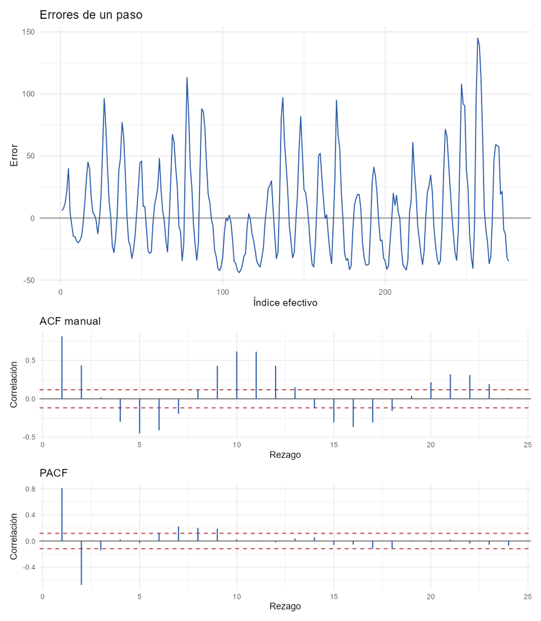

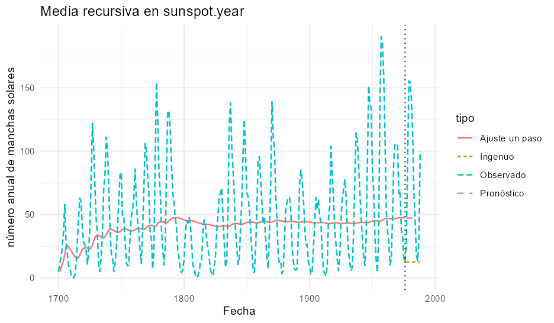

## 5.4 Conclusión y recomendación

```r
cierre_md(x)
```

**Conclusión.** Se ajustó Media recursiva con media=47.25. En las 12 observaciones de validación obtuvo MSE = 3716.425, MAD = 49.783, MAPE = 79.058 y MASE = 2.866. El referente ingenuo produjo MASE = 3.879. En los errores, Ljung–Box dio p = 3.65e-177 y la prueba de media cero dio p = 0.0024.

**Recomendación.** El resultado podría servir a ningún usuario operativo mientras se ignore el ciclo solamente hasta un horizonte de 12 años. Su límite principal es que un nivel constante contradice el ciclo solar; esto se evidencia con MASE = 2.866 y p de Ljung–Box residual = 3.65e-177.

# 6 Verificaciones numéricas

El guion `ejemplos/ejemplos.R` comprueba que la forma de corrección de error de SES coincide con su promedio ponderado y que la implementación manual de Ljung–Box coincide con `stats::Box.test()`. Por su parte, `correlograma()` conserva como atributo la máxima diferencia entre la ACF manual y `stats::acf()` y detiene la ejecución si esa diferencia no es menor que $10^{-12}$.

```r
# La mayor diferencia de cada ejemplo debe permanecer por debajo de 10^-12.
verificacion_acf <- data.frame(
  ejemplo = vapply(resultados, function(z) z$cfg$id, character(1)),
  diferencia_maxima = vapply(resultados, function(z) z$acf_diferencia, numeric(1))
)
stopifnot(all(verificacion_acf$diferencia_maxima < 1e-12))
verificacion_acf
```

```
         ejemplo diferencia_maxima
1       01-media      1.110223e-16
2          02-mm      4.440892e-16
3         03-ses      3.330669e-16
4         04-dmm      2.220446e-16
5      05-lineal      5.551115e-16
6  06-cuadratica      3.330669e-16
7 07-exponencial      5.551115e-16
8        08-holt      3.330669e-16
```

# 7 Declaración de uso de inteligencia artificial

Se utilizó asistencia de IA para organizar la estructura inicial del repositorio, proponer implementaciones y verificaciones, ampliar comentarios didácticos y construir una primera versión reproducible de este informe. La asistencia entregó código, explicaciones de sintaxis de R y propuestas de redacción, incluida la implementación del valor p exacto de Durbin–Watson por el método de Imhof (1961) y la comparación cuantitativa de series candidatas para la tendencia exponencial. El autor ejecutó las funciones, contrastó la ACF y Ljung–Box con las funciones permitidas de R, verificó por separado la implementación de Imhof contra `lmtest::dwtest()` en escenarios simulados, revisó las fórmulas y estudió el código línea por línea. Antes de entregar debe verificar personalmente todas las interpretaciones.